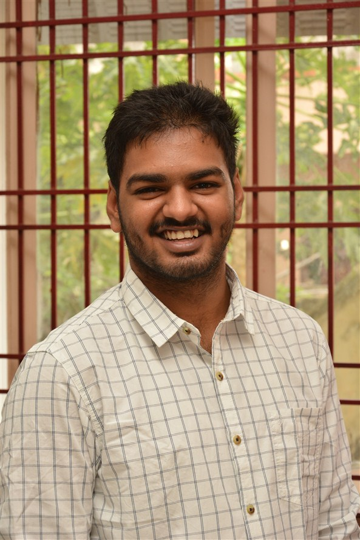

# Hari Krishna

**Hey,**

I’m currently working as a Senior Data visualization specialist at **Bristol Myers Squibb**.Describe myself as a Sport Enthusiast, passionate towards statistics & number crunching.Active member & contributor in open source community.My Blogs & Projects are majorly related to **Sports**

You can check my **Blogs,Projects,CV** in the above menu and to get in touch with me follow my social handles linked

For Better view of the site, Use **Desktop Mode**

## Experience

**Bristol Myers Squibb |** Senior Specialist-Data Visualizations **|** April 2024 - Present

- Exposure working with Posit Products-WorkBench & Connect
- Attended PHUSE SDE Hyderabad 2024-AI/ML/NLP in Clinical Trials – Challenges, Best Practices and the Road Ahead
- Attended Data Visualization in R on Clinical trials data by IASCT in Hyderabad

**DataZymes |** Associate Consultant **|** February 2022 - April 2024

- Worked on R Shiny Dashboard Development for various methodologies which include Marketing Mix Modelling,Test & Control Analysis,Campaign Analysis
- Implemented Machine learning modules in the dashboard
- Developing efficient backend code using Python for various dashboards with optimized code structure and performance.

**Prodian Infotech |** Data Analyst **|** May 2021 - January 2022

- Effectively used ML algorithms(Classification,Clustering) on Car Insurance Data
- Worked on Automated ML platform-Data Robot
- Carried out EDA process and calculated statistical measures for important variables

**Kabaddi Adda** | Analyst | Intern | November 2020 - February 2021

- Built Player Comparison Dashboard using R Shiny
- Exploratory Data Analysis on Pro Kabaddi data
- Identifying key player metrics for analysis

## Education

**Christ University** | Bangalore, India

Master’s in Data Science | June 2019-April 2021

**Loyola Degree & PG College** | Telangana, India

B.S.C. in Mathematics,Statistics & Computer Science | June 2016 - April 2019